# Task 7 - Basic visualization with R

Bowen Tan

2026-10-30

### Load packages

```r
library(tidyverse)
```

## 1. Compare the distributions of the body heights of the two species from the ‘magic_guys.csv’ dataset graphically

### a. using the basic ‘hist’ function as well as ‘ggplot’ and ‘geom_histogram’ functions from the ggplot2 package. Optimize the plots for example by trying several different ‘breaks’. Note that ggplot2-based functions give you many more options for changing the visualization parameters, try some of them.

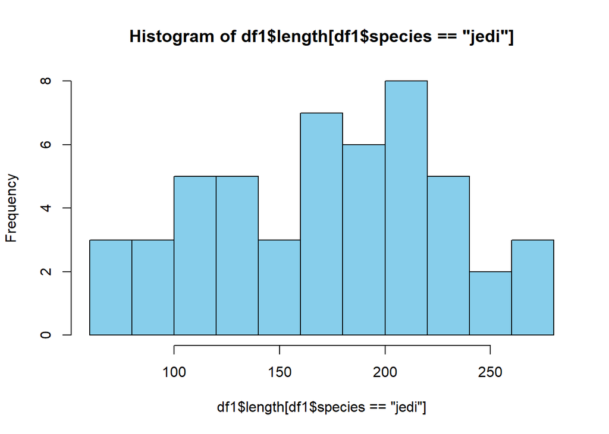

```r
# Load dataset
df1 <- read.csv("Week 1 - data for Task 7/magic_guys.csv")

# Plot with "hist"
hist(df1$length[df1$species == "jedi"],
     breaks = 10,
     col = "skyblue")
```

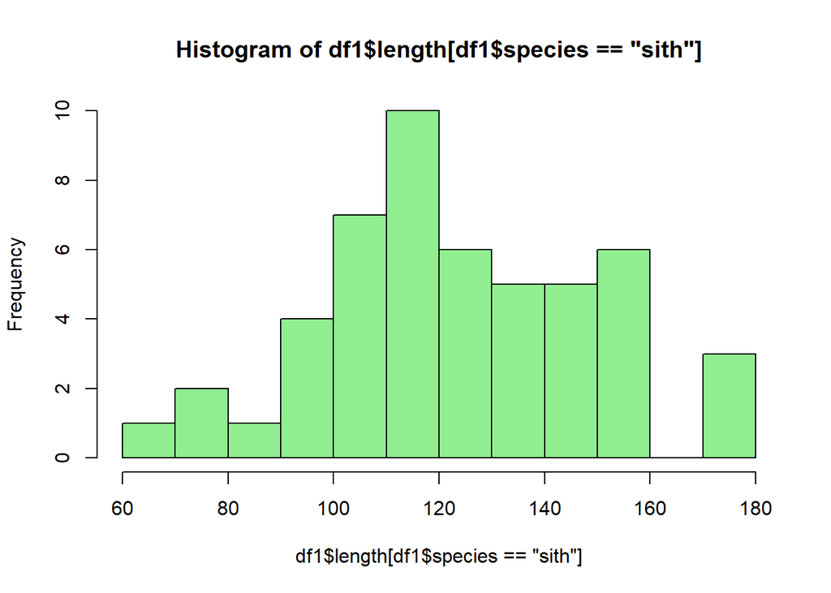

```r
hist(df1$length[df1$species == "sith"],
     breaks = 10,
     col = "lightgreen")
```

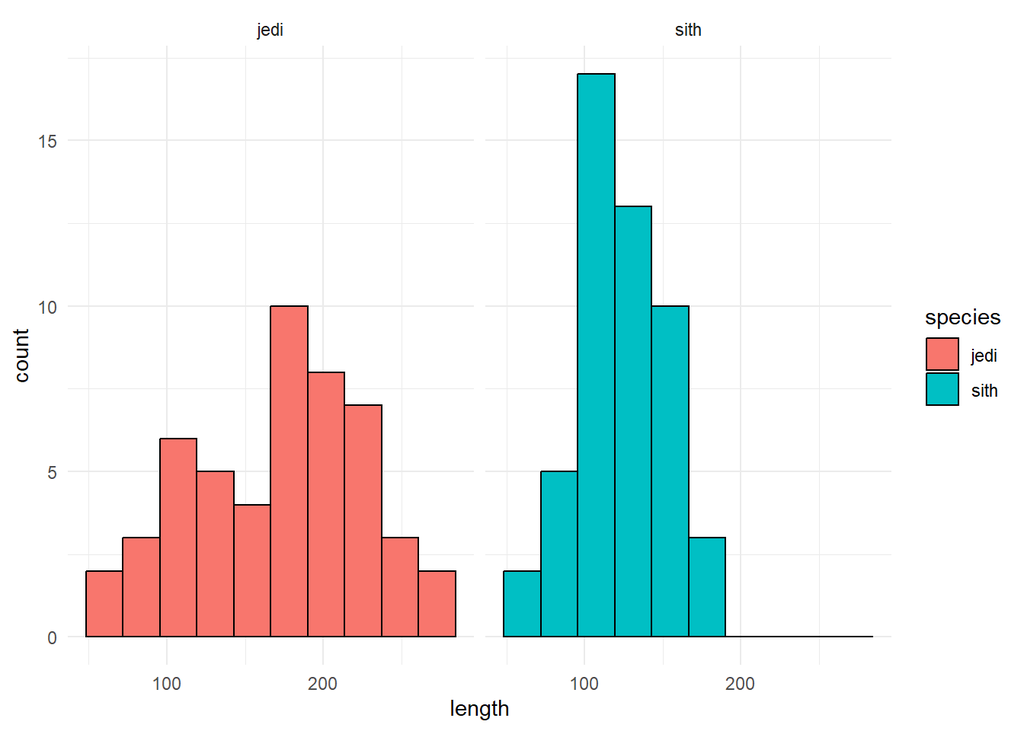

```r
# Plot with ggplot2
p1 <- ggplot(df1, aes(x = length, fill = species)) +
  geom_histogram(bins = 10, color = "black") +
  facet_wrap(~species) +
  theme_minimal()

p2 <- ggplot(df1, aes(x = length, fill = species)) +
  geom_histogram(bins = 20, color = "black") +
  facet_wrap(~species) +
  theme_minimal()

p1
```

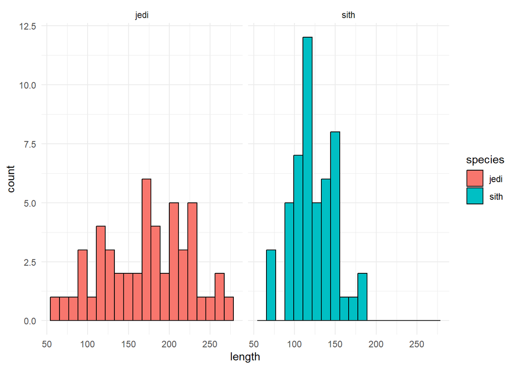

```r
p2
```

### b. Do the same comparison as in a. but with boxplots. If you want to use the ggplot2-package, use the functions ‘ggplot’ and ‘geom_boxplot’.

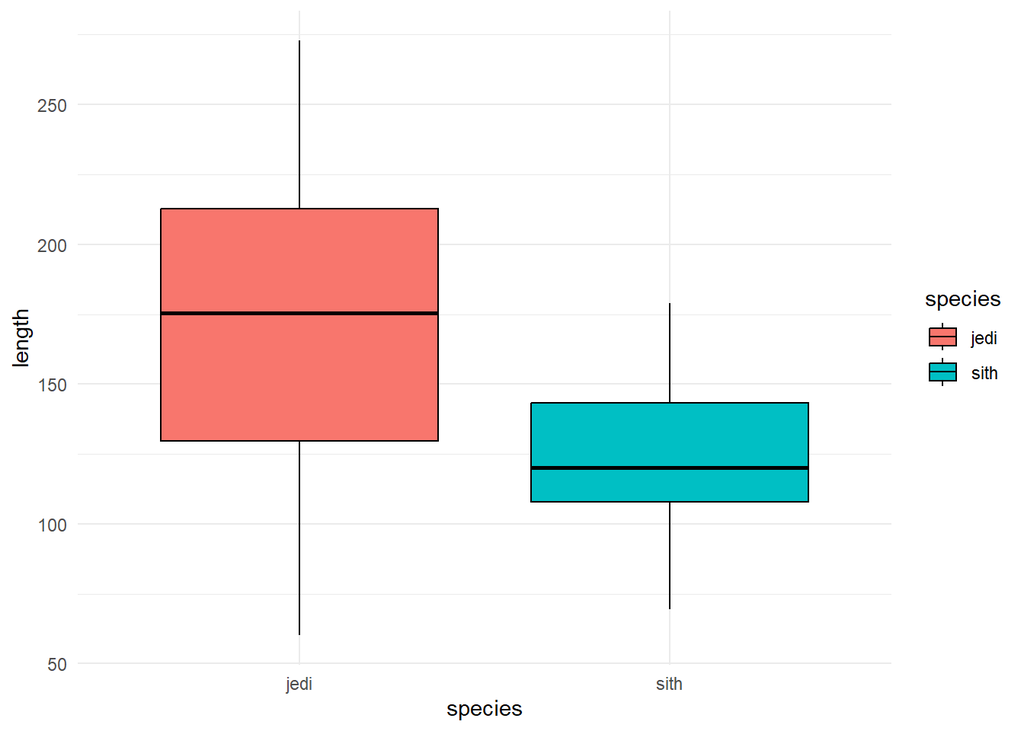

```r
p3 <- ggplot(df1, aes(x = species, y = length, fill = species)) +
  geom_boxplot(color = "black") +
  theme_minimal()

p3
```

### c. Save the plots with the ‘png’, ‘pdf’, and ‘svg’ formats. In which situation would you use which file format?

```r
# Save as png
ggsave("histogram.png", plot = p2)
ggsave("boxplot.png", plot = p3)
# Save as pdf
ggsave("histogram.pdf", plot = p2)
ggsave("boxplot.pdf", plot = p3)
# Save as svg
ggsave("histogram.svg", plot = p2)
ggsave("boxplot.svg", plot = p3)
```

PNG is suitable for presentations, web pages, and reports because it provides high-quality raster images that are widely supported. PDF is preferable for scientific publications and printing because it stores graphics as vectors. SVG is also a vector format and is particularly useful for web graphics and further editing in vector graphic software such as Adobe Illustrator, but it is less commonly required by scientific journals.

## 2. Load the gene expression data matrix from the ‘microarray_data.tab’ dataset provided in the shared folder, it is a big tabular separated matrix.

### a. How big is the matrix in terms of rows and columns?

```r
# Load dataset
df2 <- read.delim("Week 1 - data for Task 7/microarray_data.tab")

# Check for numbers of rows and columns
dim(df2)
```

```
## [1]  553 1000
```

There are 553 rows and 1000 columns in the matrix.

### b. Count the missing values per gene and visualize this result.

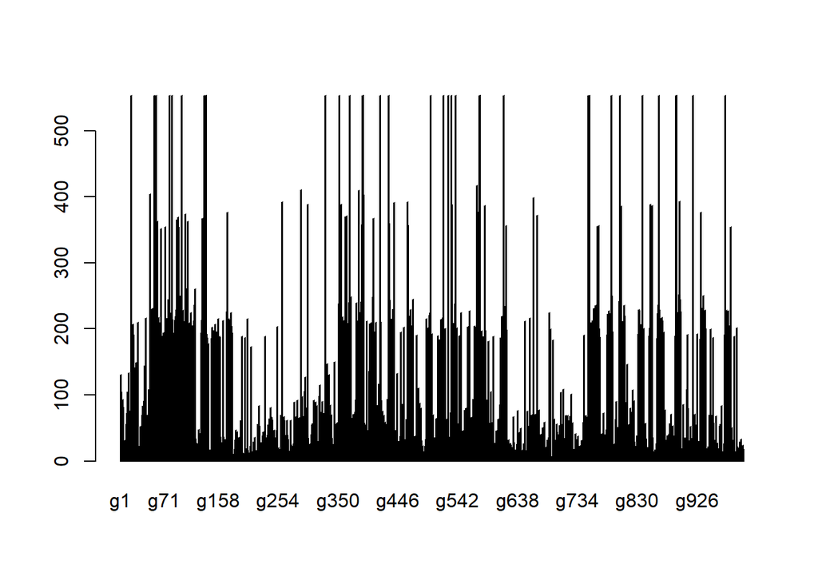

```r
# Count the missing values per gene
na_per_gene <- colSums(is.na(df2))

# Visualization
barplot(na_per_gene)
```

### c. Find the genes for which there are more than X% (X=10%, 20%, 50%) missing values.

```r
# Percentage of missing values per gene
na_percentage <- colMeans(is.na(df2)) * 100

# More than X%
genes_10 <- names(na_percentage[na_percentage > 10])
genes_20 <- names(na_percentage[na_percentage > 20])
genes_50 <- names(na_percentage[na_percentage > 50])

genes_10
```

```
##   [1] "g1"   "g2"   "g3"   "g4"   "g5"   "g10"  "g11"  "g12"  "g14"  "g15"
##  [11] "g16"  "g18"  "g21"  "g22"  "g23"  "g24"  "g25"  "g26"  "g28"  "g29"
##  [21] "g35"  "g36"  "g37"  "g38"  "g39"  "g40"  "g41"  "g42"  "g44"  "g45"
##  [31] "g46"  "g47"  "g48"  "g49"  "g50"  "g51"  "g52"  "g53"  "g54"  "g55"
##  [41] "g56"  "g57"  "g58"  "g59"  "g60"  "g61"  "g62"  "g63"  "g64"  "g65"
##  [51] "g66"  "g67"  "g68"  "g69"  "g70"  "g71"  "g72"  "g73"  "g74"  "g75"
##  [61] "g76"  "g77"  "g78"  "g79"  "g80"  "g81"  "g82"  "g83"  "g84"  "g85"
##  [71] "g86"  "g87"  "g88"  "g89"  "g90"  "g91"  "g92"  "g93"  "g94"  "g95"
##  [81] "g96"  "g97"  "g98"  "g99"  "g100" "g101" "g102" "g103" "g104" "g105"
##  [91] "g106" "g107" "g108" "g109" "g110" "g111" "g112" "g113" "g114" "g115"
## [101] "g116" "g117" "g118" "g119" "g120" "g130" "g131" "g132" "g133" "g134"
## [111] "g135" "g136" "g137" "g138" "g139" "g140" "g142" "g147" "g148" "g151"
## [121] "g152" "g153" "g154" "g155" "g156" "g157" "g158" "g159" "g160" "g165"
## [131] "g171" "g172" "g173" "g174" "g175" "g176" "g177" "g178" "g179" "g180"
## [141] "g194" "g196" "g200" "g204" "g210" "g221" "g223" "g233" "g239" "g241"
```

[output cut: 38 more lines]

```r
genes_20
```

```
##   [1] "g1"   "g14"  "g18"  "g21"  "g22"  "g24"  "g25"  "g26"  "g29"  "g39"
##  [11] "g40"  "g41"  "g48"  "g51"  "g52"  "g53"  "g54"  "g55"  "g56"  "g57"
##  [21] "g58"  "g59"  "g60"  "g61"  "g62"  "g63"  "g64"  "g65"  "g66"  "g67"
##  [31] "g68"  "g69"  "g70"  "g71"  "g72"  "g73"  "g74"  "g75"  "g76"  "g77"
##  [41] "g78"  "g79"  "g80"  "g81"  "g82"  "g83"  "g84"  "g85"  "g86"  "g87"
##  [51] "g88"  "g89"  "g90"  "g91"  "g92"  "g93"  "g94"  "g95"  "g96"  "g97"
##  [61] "g98"  "g99"  "g100" "g101" "g102" "g103" "g104" "g105" "g106" "g107"
##  [71] "g108" "g109" "g110" "g111" "g112" "g113" "g114" "g115" "g116" "g117"
##  [81] "g118" "g119" "g120" "g130" "g131" "g132" "g133" "g134" "g135" "g136"
##  [91] "g137" "g138" "g139" "g140" "g142" "g147" "g148" "g151" "g152" "g153"
## [101] "g154" "g155" "g156" "g157" "g158" "g159" "g160" "g165" "g171" "g172"
## [111] "g173" "g174" "g175" "g176" "g177" "g178" "g179" "g180" "g196" "g200"
## [121] "g204" "g210" "g233" "g252" "g260" "g290" "g297" "g301" "g321" "g329"
## [131] "g332" "g333" "g334" "g335" "g344" "g351" "g352" "g353" "g354" "g355"
## [141] "g356" "g357" "g358" "g359" "g360" "g361" "g362" "g363" "g364" "g365"
```

[output cut: 23 more lines]

```r
genes_50
```

```
##  [1] "g18"  "g48"  "g55"  "g58"  "g60"  "g66"  "g73"  "g79"  "g83"  "g91"
## [11] "g93"  "g94"  "g99"  "g105" "g109" "g132" "g135" "g137" "g138" "g172"
## [21] "g260" "g290" "g301" "g329" "g352" "g355" "g362" "g363" "g368" "g383"
## [31] "g388" "g389" "g390" "g391" "g406" "g417" "g431" "g432" "g440" "g461"
## [41] "g462" "g498" "g519" "g527" "g531" "g532" "g538" "g572" "g575" "g576"
## [51] "g577" "g585" "g615" "g619" "g663" "g669" "g751" "g753" "g766" "g768"
## [61] "g788" "g802" "g804" "g838" "g851" "g854" "g864" "g892" "g893" "g898"
## [71] "g919" "g932" "g971" "g980"
```

### d. Replace the missing values by the average expression value for the particular gene. (Note: Imputing data has to be used with caution!)

```r
df2_imputed <- as.data.frame(
  lapply(df2, function(x) {
    x[is.na(x)] <- mean(x, na.rm = TRUE)
    x
  })
)

# Check NA left
sum(is.na(df2_imputed))
```

```
## [1] 18802
```

```r
18802/553
```

```
## [1] 34
```

There are 34 genes with all missing values.

## 3. Visualize the data in the CO2 dataset in a way that gives you a deeper understanding of the data. What do you see?

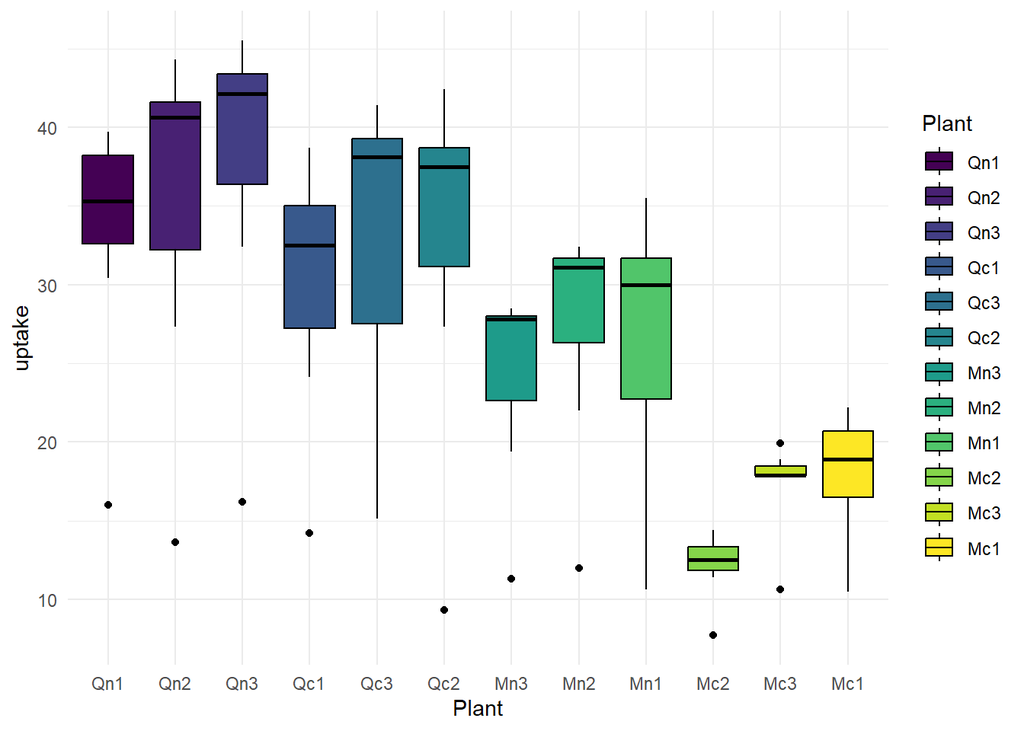

```r
# Load dataset
data(CO2)

# Uptake by plant
ggplot(CO2, aes(x = Plant, y = uptake, fill = Plant)) +
  geom_boxplot(color = "black") +
  theme_minimal()
```

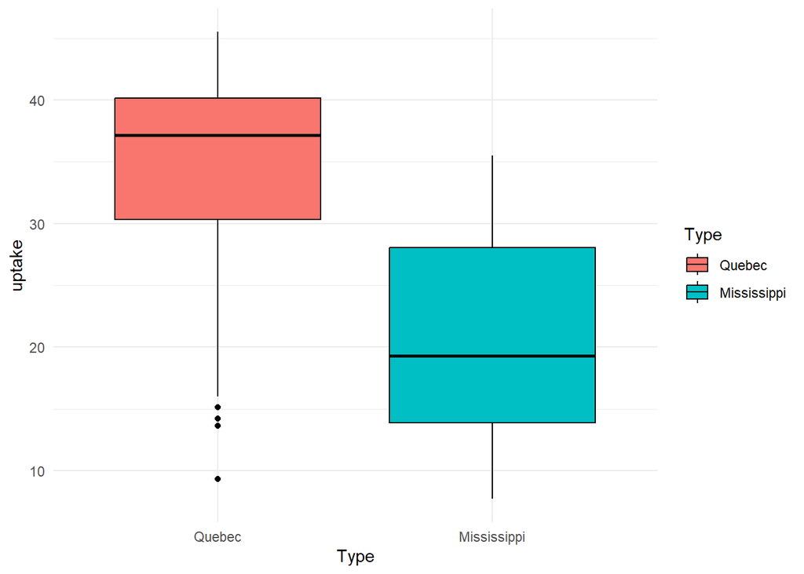

```r
# Uptake by type
ggplot(CO2, aes(x = Type, y = uptake, fill = Type)) +
  geom_boxplot(color = "black") +
  theme_minimal()
```

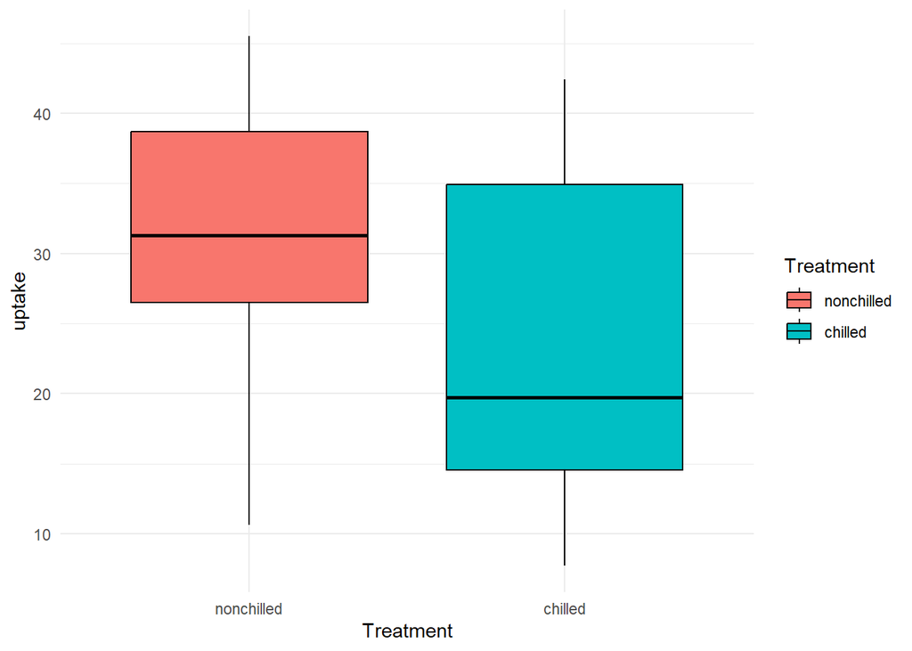

```r
# Uptake by treatment
ggplot(CO2, aes(x = Treatment, y = uptake, fill = Treatment)) +
  geom_boxplot(color = "black") +
  theme_minimal()
```

For plant, Qn3 has the highest CO2 uptake. The order from high to low is Qn, Qc, Mn, Mc.

For type, Quebec has higher CO2 uptake than Mississippi.

For treatment, nonchiiled treatment has higher CO2 uptake than chilled treatment.